# Bellabeat Case Study

Levi Tyer

2022-07-04

## Business Case:

Bellabeat wants to gain a greater foothold in the wearable fitness tracker marketplace by understanding how women use competing products. The company is interested in usage trends for competing products, specifically FitBit. By understanding how users engage with these devices and identifying potential areas of improvement, Bellabeat hopes to evolve and tailor their existing products to better suit the primary demographic of wellness technology wearers.

Specifically, findings from this analysis will be used to provide recommendations to Bellabeat’s Time wellness tracker, a device that tracks the user’s activity, sleep, and stress, as well as the corresponding app which logs device data and informs users of their habits.

## Data Preparation

The data used for this exploratory analysis comes from FitBit Fitness Tracker Data available on Kaggle, courtesy of Mobius for public use. The dataset contains continuous output for a range of bio metrics collected on 33 volunteering FitBit users. To best align with with Bellabeat’s current product line, this analysis will focus on features that overlap with Fitbit’s offerings - namely sedentary time, activity time, and sleep habits.

Data set was assessed for type errors, range constraints, and full duplicates. Due to the data being derived from each participant’s daily metrics, partial duplicates are inherent to the data set and are not altered.

```r
# load data
activity_table <- read_csv("Fitabase Data 4.12.16-5.12.16/dailyActivity_merged.csv")
sleep_table <- read_csv("Fitabase Data 4.12.16-5.12.16/sleepDay_merged.csv")
weight_table <- read_csv("Fitabase Data 4.12.16-5.12.16/weightLogInfo_merged.csv")
# convert dates into appropriate object
activity_table <- activity_table %>% mutate(ActivityDate = mdy(activity_table$ActivityDate))
sleep_table <- sleep_table %>% mutate(SleepDay = mdy_hms(sleep_table$SleepDay))
weight_table <- weight_table %>% mutate(Date = mdy_hms(weight_table$Date))
# check for full duplicates
sum(duplicated(activity_table))
```

```
## [1] 0
```

```r
sum(duplicated(sleep_table)) # returns 3 duplicated rows
```

```
## [1] 3
```

```r
sum(duplicated(weight_table))
```

```
## [1] 0
```

```r
# identify and remove duplicates
filter(sleep_table, duplicated(sleep_table))
```

```
## # A tibble: 3 × 5
##          Id SleepDay            TotalSleepRecor… TotalMinutesAsl… TotalTimeInBed
##       <dbl> <dttm>                         <dbl>            <dbl>          <dbl>
## 1    4.39e9 2016-05-05 00:00:00                1              471            495
## 2    4.70e9 2016-05-07 00:00:00                1              520            543
## 3    8.38e9 2016-04-25 00:00:00                1              388            402
```

```r
sleep_table <- distinct(sleep_table)
sum(duplicated(sleep_table))
```

```
## [1] 0
```

## Analysis and Visualization

```r
# general table stats
n_distinct(activity_table$Id)
```

```
## [1] 33
```

```r
row_count <- nrow(activity_table)
# summary statistics for columns of interest
activity_table %>%
  select(TotalSteps,
         TotalDistance,
         SedentaryMinutes) %>%
  summary()
```

```
##    TotalSteps    TotalDistance    SedentaryMinutes
##  Min.   :    0   Min.   : 0.000   Min.   :   0.0
##  1st Qu.: 3790   1st Qu.: 2.620   1st Qu.: 729.8
##  Median : 7406   Median : 5.245   Median :1057.5
##  Mean   : 7638   Mean   : 5.490   Mean   : 991.2
##  3rd Qu.:10727   3rd Qu.: 7.713   3rd Qu.:1229.5
##  Max.   :36019   Max.   :28.030   Max.   :1440.0
```

```r
# count of rows that suggests device wasn't worn for given day
zero_steps_count <- count(activity_table %>%
  filter(TotalSteps == 0))
# count of rows that record max amount of sedentary minutes
sedentary_max <- count(activity_table %>%
  filter(SedentaryMinutes == 1440))
# find percentage of days that device possibly wasn't worn
zero_steps_percentage <- (zero_steps_count / row_count) * 100
sedentary_max_percentage <- (sedentary_max / row_count) * 100
# assess difference between the two metrics
sedentary_max_percentage - zero_steps_percentage
```

```
##          n
## 1 0.212766
```

```r
# find rows with the max sedentary minutes that somehow also have steps
activity_table %>%
  filter(TotalSteps != 0 & SedentaryMinutes == 1440) %>%
  select(Id, TotalSteps, SedentaryMinutes)
```

```
## # A tibble: 7 × 3
##           Id TotalSteps SedentaryMinutes
##        <dbl>      <dbl>            <dbl>
## 1 4319703577       7753             1440
## 2 4388161847      10122             1440
## 3 8583815059       5319             1440
## 4 8583815059       3008             1440
## 5 8583815059       8469             1440
## 6 8583815059      12015             1440
## 7 8583815059       3588             1440
```

When comparing steps taken to sedentary minutes, it appears that there isn’t necessarily an inverse relationship between the two. The data shows that during more sedentary days, users still often track roughly similar steps as less sedentary days, suggesting that a lot of people likely have long periods of inactivity with bouts of movement in between. The data point coloring shows that rather than have two main clusters of separate users, each users tends to have varying activity.

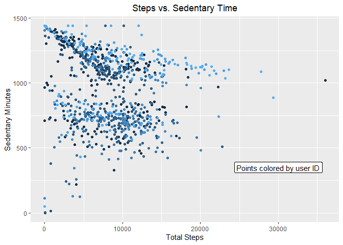

```r
activity_table %>%
  ggplot(aes(x=TotalSteps, y=SedentaryMinutes, color=Id)) +
  geom_point() +
  labs(x = "Total Steps",
       y = "Sedentary Minutes",
       title = "Steps vs. Sedentary Time") +
  theme(plot.title = element_text(hjust = 0.5), legend.position = "none") +
  annotate("label",
           x = 30000,
           y = 350,
           label = "Points colored by user ID")
```

The time that users spend in bed correlates fairly well with the amount of sleep they achieved. There are some notable groupings that stand out from this linear progression, however. The standouts are consistent in that the time they spend in bed equates to less than the average amount of sleep. It is likely that these divergent data points are due to either struggles to sleep or lounging. Here, we see that the deviant data points are from a particular subset of users as identified by their ID colors. These users likely have a harder time falling asleep or different nighttime routines than the main userbase.

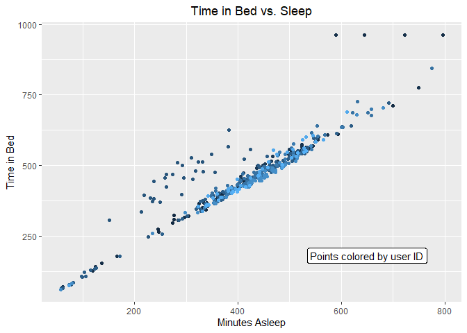

```r
sleep_table %>%
  ggplot(aes(x=TotalMinutesAsleep, y=TotalTimeInBed, color=Id)) +
  geom_point() +
  labs(x = "Minutes Asleep",
       y = "Time in Bed",
       title = "Time in Bed vs. Sleep") +
  theme(plot.title = element_text(hjust = 0.5), legend.position = "none") +
  annotate("label",
           x = 650,
           y = 180,
           label = "Points colored by user ID")
```

Combining the two table to ascertain whether there is any relation between a users activity for the day and the amount of time they slept.

```r
# Merge the two datasets into a single table
combined_data <- merge(sleep_table, activity_table, by="Id", all=TRUE)
# Make sure the number of Ids match up
n_distinct(combined_data$Id)
```

```
## [1] 33
```

```r
n_distinct(activity_table$Id)
```

```
## [1] 33
```

The relationship between activity and sleep displayed as a boxplot with time slept grouped in intervals of 100 minutes for readability. There doesn’t seem to be any evident relationship between the two variables.

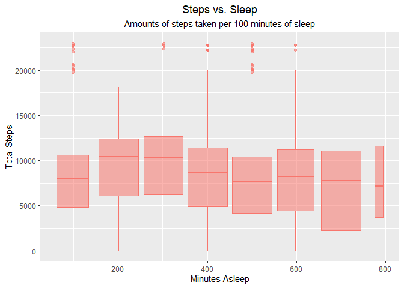

```r
combined_data %>%
  ggplot(mapping = aes(x=TotalMinutesAsleep, y=TotalSteps)) +
  geom_boxplot(mapping = aes(group = cut_width(TotalMinutesAsleep, 100), color = "red", fill = "orange", alpha = 0.2), na.rm = TRUE) +
  labs(x = "Minutes Asleep",
       y = "Total Steps",
       title = "Steps vs. Sleep",
       subtitle = "Amounts of steps taken per 100 minutes of sleep") +
  theme(plot.title = element_text(hjust = 0.5), plot.subtitle = element_text(hjust = 0.5), legend.position = "none") +
  theme(legend.position = "none")
```

Next, total times at different activity levels will be analyzed to determine exactly how FitBit users are splitting their activity levels. By taking the mean of each activity level: very active, fairly active, and lightly active, we can get a breakdown of the general user’s habits. Through the bar graph, we can see that the vast majority of active minutes is spent in the “Lightly Active” category. In fact, for the generalized user, the very and moderately active categories combined equate to less than an hour out of the users day. A potential inference from this summary is that, while most FitBit users may be health and fitness conscious, may are not performing athletic activity with any consistency.

According to a study done by the American College of Rheumatology and their communications with Fitabase (a popular platform for exporting fitness data), FitBit’s criteria for activity is derived from calculations performed on metabolic equivalent tasks (METs).<sup>2</sup> A MET, another study done on it’s relationship with exercise, is defined as “the amount of oxygen consumed while sitting at rest and is equal to 3.5 ml O2 per kg body weight x min.”<sup>3</sup>

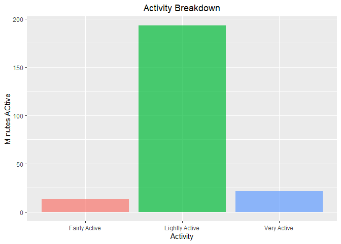

```r
# calculate the mean for each activity category
mean_very_active <- mean(activity_table$VeryActiveMinutes)
mean_fairly_active <- mean(activity_table$FairlyActiveMinutes)
mean_lightly_active <- mean(activity_table$LightlyActiveMinutes)
# organize the means into a tibble for ease of visualization
activity_means <- tibble(active_names = c("Very Active", "Fairly Active", "Lightly Active"), minutes_active_mean = c(mean_very_active, mean_fairly_active, mean_lightly_active))
# bar graph displaying the means
activity_means %>%
  ggplot(aes(x = active_names, y = minutes_active_mean, fill = active_names)) +
  labs(x = "Activity",
       y = "Minutes ACtive",
       title = "Activity Breakdown") +
  theme(plot.title = element_text(hjust = 0.5), legend.position = "none") +
  geom_bar(alpha = 0.7, position = "dodge", stat = "identity")
```

Trends in individual user weight show relatively stable values with little change across the month long period. However, significant weight loss is not usually seen in such a short span of time. It also remains unknown whether users were actively trying to adjust their weight as assumptions might usually dictate. More data and demographic information would be needed for further insight.

What is apparent is the inconsistency in tracking overall. Only eight of the thirty three users involved in the study tracked their weight. Of those eight, only two were consistent in recording their values. Further research should be done into how to motive users to engage with this feature.

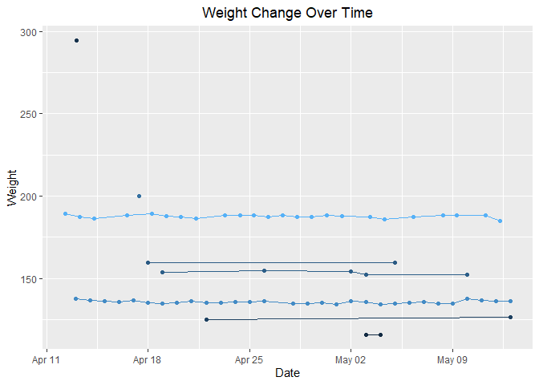

```r
weight_table %>%
  ggplot(aes(x = Date, y = WeightPounds, group = Id, color = Id)) +
    geom_line() +
    geom_point() +
  labs(y = "Weight",
       title = "Weight Change Over Time") +
  theme(plot.title = element_text(hjust = 0.5), legend.position = "none") +
  scale_fill_manual()
```

## Recommendations

Based the activity summary statistics and weight logging, FitBit users show a noticable level of inconsistency in device usage. If Bellabeat wishes to capture higher levels of engagement than their competitors, notifications sent out through the app will likely be the best way to remind users to wear the wellness tracker. Reminders should be unobtrusive and follow-up user acceptance testing is suggested to identify effective strategies that don’t frustrate the user.

Summary statistics also found some inconsistency in the way that FitBit is tracking steps. There were seven entries in the study where a user recorded the maximum amount of sedentary minutes in a day while simultaneously tracking steps. Being completely sedentary for the entire day is not likely, suggesting that the device was not worn. In the event that the user was sedentary for such a long amount of time, initial assumptions may suggest that the steps taken could be low enough as to be completed in a minute, however, several of the entries recorded an excess of ten thousand steps. There would appear to be some issue with the way FitBit’s device is recording or calculating those two metrics. Further testing on Bellabeat’s devices is recommended to ensure they don’t suffer from the same inconsistency.

Comparison of user steps to sedentary time, along with the activity breakdown, suggest that the average user isn’t necessarily leading an active lifestyle. Marketing initiatives should receive the largest returns by appealing to the health conscious consumer that leads a fairly typical lifestyle, rather than the active or athletic sectors.

Effective tracking of user sleep patterns and making that information available to them seems to be a worthwhile investment. There were multiple instances where a user spent significantly more time in bed than asleep. Informing the user of these trends and providing helpful tips on how to achieve quality rest could be of great benefit to Bellabeat’s consumers, increasing brand loyalty and the perception of the wellness tracker as a useful part of their lives.

The weight tracking feature, however, was shown to be poorly utilized. Only a handful of the users in the study tracked their weight with even fewer doing it consistently. Thus, implementing this functionality into BellaBeat’s products does not appear to be a worthwhile investment at this time.

## References

1. Mobius, FitBit Fitness Tracker Data. Kaggle version. 2020. Web. 04 July 2022.
2. Semanik, P., Lee, J., Pellegrini, C.A., Song, J., Dunlop, D.D. and Chang, R.W. (2020), Comparison of Physical Activity Measures Derived From the Fitbit Flex and the ActiGraph GT3X+ in an Employee Population With Chronic Knee Symptoms. ACR Open Rheumatology, 2: 48-52. https://doi.org/10.1002/acr2.11099
3. Jetté M, Sidney K, Blümchen G. Metabolic equivalents (METS) in exercise testing, exercise prescription, and evaluation of functional capacity. Clin Cardiol. 1990 Aug;13(8):555-65. doi: 10.1002/clc.4960130809. PMID: 2204507.